# Python Workshop

**Author**: Miguel Alexandre

# What do I need?

```python
# Most data handling
import pandas as pd

# Array operations
import numpy as np

# Plotting
import matplotlib.pyplot as plt
from matplotlib import colormaps as cmap
plt.style.use("default")

%matplotlib inline

# Scientific tools
from scipy.ndimage import gaussian_filter1d

# Other
import os
```

# Where are my files??

```python
pwd
```

```
'/home/miguel/Documents/CEMOP/Workshop/Python'
```

```python
ls
```

```
assets/                            first_fig.svg
Cell_Characterization/             QD_Characterization/
Cell_Electrical_Characterization/  Viscosidade/
DRX/                               Workshop_Base.ipynb
Ellipsometry/                      Workshop_Solutions.ipynb
first_fig.png
```

# How to import data?

```python
%%html
<iframe src="https://pandas.pydata.org/docs/reference/api/pandas.read_csv.html" width="1200" height="1000"></iframe>
```

[interactive chart not shown]

```python
# Reading documention from jupyter notebook directly
?pd.read_csv
```

```
Signature:
pd.read_csv(
    filepath_or_buffer: 'FilePath | ReadCsvBuffer[bytes] | ReadCsvBuffer[str]',
    *,
    sep: 'str | None | lib.NoDefault' = <no_default>,
    delimiter: 'str | None | lib.NoDefault' = None,
    header: "int | Sequence[int] | None | Literal['infer']" = 'infer',
    names: 'Sequence[Hashable] | None | lib.NoDefault' = <no_default>,
    index_col: 'IndexLabel | Literal[False] | None' = None,
    usecols: 'UsecolsArgType' = None,
    dtype: 'DtypeArg | None' = None,
    engine: 'CSVEngine | None' = None,
    converters: 'Mapping[Hashable, Callable] | None' = None,
    true_values: 'list | None' = None,
    false_values: 'list | None' = None,
    skipinitialspace: 'bool' = False,
    skiprows: 'list[int] | int | Callable[[Hashable], bool] | None' = None,
    skipfooter: 'int' = 0,
    nrows: 'int | None' = None,
    na_values: 'Hashable | Iterable[Hashable] | Mapping[Hashable, Iterable[Hashable]] | None' = None,
    keep_default_na: 'bool' = True,
    na_filter: 'bool' = True,
    verbose: 'bool | lib.NoDefault' = <no_default>,
    skip_blank_lines: 'bool' = True,
    parse_dates: 'bool | Sequence[Hashable] | None' = None,
    infer_datetime_format: 'bool | lib.NoDefault' = <no_default>,
    keep_date_col: 'bool | lib.NoDefault' = <no_default>,
    date_parser: 'Callable | lib.NoDefault' = <no_default>,
    date_format: 'str | dict[Hashable, str] | None' = None,
    dayfirst: 'bool' = False,
    cache_dates: 'bool' = True,
    iterator: 'bool' = False,
    chunksize: 'int | None' = None,
    compression: 'CompressionOptions' = 'infer',
    thousands: 'str | None' = None,
    decimal: 'str' = '.',
    lineterminator: 'str | None' = None,
    quotechar: 'str' = '"',
    quoting: 'int' = 0,
    doublequote: 'bool' = True,
```

[output cut: 385 more lines]

```
DataFrame or TextFileReader
    A comma-separated values (csv) file is returned as two-dimensional
    data structure with labeled axes.

See Also
--------
DataFrame.to_csv : Write DataFrame to a comma-separated values (csv) file.
read_table : Read general delimited file into DataFrame.
read_fwf : Read a table of fixed-width formatted lines into DataFrame.

Examples
--------
>>> pd.read_csv('data.csv')  # doctest: +SKIP
File:      ~/anaconda3/lib/python3.12/site-packages/pandas/io/parsers/readers.py
Type:      function
```

# Handling Data

## First Example

To edit data it is fundamental to first open the file and check if everything is ok, and all the necessary properties to consider, such as the data separators, lines to ignore, how the data is setup, the decimal delimiter

**Import and plot the data in "Cell_Characterization/Spectrophotometry/Rd_Flat-Si_600nmTiO2_100s.Sample.Raw.csv"**

```python
data = pd.read_csv("Cell_Characterization/Spectrophotometry/Rd_Flat-Si_600nmTiO2_100s.Sample.Raw.csv",
                   sep=";", decimal=",", names=["wvl", "R"], header=0)
```

```python
# Basic Pandas operations
data
data["wvl"]
data.head(10)
data.tail(10)
data**2
data["wvl"]+data["R"]
data.columns
data.index
data[data.index % 2 == 0]
data.query("index % 2 == 0 and wvl > 1590")
data.describe()
data.apply(lambda x: x.max() - x.min())
```

```
wvl    1350.000000
R        29.055389
dtype: float64
```

# Anatomy of a Figure

[figure not shown]

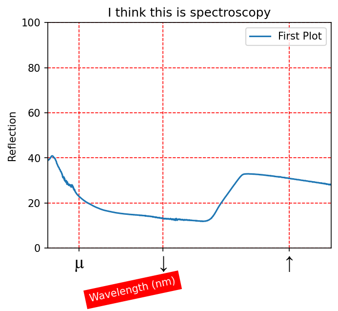

```python
# Basic Plotting
plt.plot(data.wvl, data.R, label="First Plot")
plt.xlabel("Wavelength (nm)", x=0.3, rotation=12, backgroundcolor="red", color="white")
plt.ylabel("Reflection")
plt.title("I think this is spectroscopy")
plt.xticks([400, 800, 1400], ["µ", "↓", "↑"], font="Times New Roman", fontsize=18)
plt.ylim(0, 100)
plt.xlim(250, 1600)
plt.grid(linestyle="--", color="red")
plt.legend()
# Magic
# plt.rcParams["svg.fonttype"] = "none"
# plt.savefig("first_plot.svg", dpi=300, bbox_inches="tight")
```

## Exercice 1

**Exercise 1.1*:** Import the DRX data in "QD_Characterization/G211014B_dropcastfilm.txt" and plot it (Angle vs Intensity)

```python
data = pd.read_csv("QD_Characterization/G211014B_dropcastfilm.txt",
                  sep="\t", skiprows=1)
```

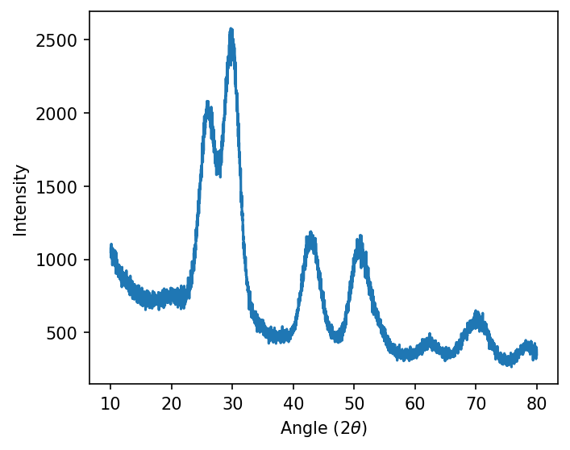

```python
plt.plot(data.Angle, data.Intensity)
plt.xlabel(r"Angle (2$\theta$)")
plt.ylabel("Intensity")
```

**Exercise 1.2***: Import and plot the spectrophotometry data in "Cell_Characterization/Spectrophotometry_2"

The plot should be the Reflection/Transmission vs Wavelength

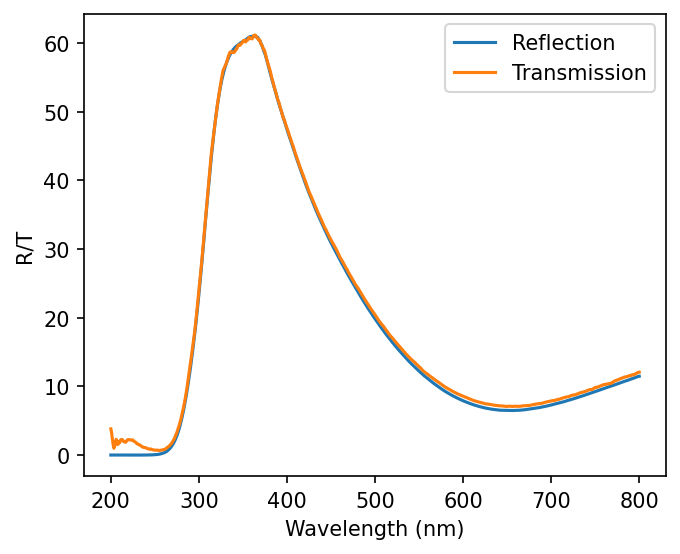

```python
reflection = pd.read_csv("Cell_Characterization/Spectrophotometry_2/HR_G3_RE.ASC", names=["wvl", "R"])
transmission = pd.read_csv("Cell_Characterization/Spectrophotometry_2/HR_G3_TT.ASC", names=["wvl", "T"])
data = reflection.merge(transmission)
plt.plot(data.wvl, data.R, label="Reflection")
plt.plot(data.wvl, data["T"], label="Transmission")
plt.xlabel("Wavelength (nm)")
plt.ylabel("R/T")
plt.legend()
```

**Exercise 1.3***: Import the DRX data in "DRX/*.txt" and make an intensity offset plot for each data with different cycles

```python
cycle_400 = "DRX/AZO180_19_400cycles.txt"
cycle_800 = "DRX/AZO_180C_19_1_800cycles.txt"
cycle_1200 = "DRX/AZO_180C_19_1_1200cycles.txt"

c400 = pd.read_csv(cycle_400, sep="\t", names=["Angle", "Intensity"])
c800 = pd.read_csv(cycle_800, sep="\t", names=["Angle", "Intensity"])
c1200 = pd.read_csv(cycle_1200, sep="\t", names=["Angle", "Intensity"])
```

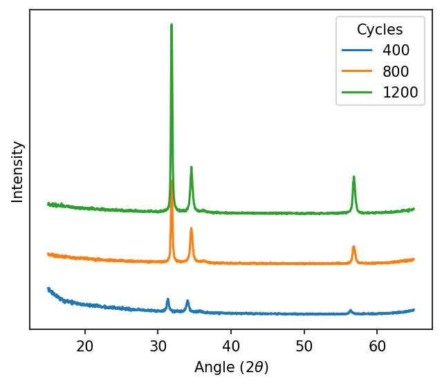

```python
plt.plot(c400.Angle, c400.Intensity, label="400")
plt.plot(c800.Angle, c800.Intensity+1000, label="800")
plt.plot(c1200.Angle, c1200.Intensity+2000, label="1200")
plt.xlabel("Angle (2$\\theta$)")
plt.ylabel("Intensity")
plt.yticks([])
plt.legend(title="Cycles")
```

**Exercise 1.4*:** Import the absorption data in "QD_Characterization/020223_dots.csv" and plot it for each sample (Wavelength vs Absorption)

```python
ex1_data = pd.read_csv("QD_Characterization/020223_dots.csv",
                       usecols=[0, 1, 3, 5, 7, 9],
                       skipfooter=265,
                       skiprows=2,
                       names=["wvl", "S1", "S2", "S3", "S4", "S5"],
                       engine="python")
ex1_data
```

|  | wvl | S1 | S2 | S3 | S4 | S5 |
| --- | --- | --- | --- | --- | --- | --- |
| 0 | 1400 | -0.004247 | 0.000909 | -0.004421 | -0.003084 | -0.004220 |
| 1 | 1399 | -0.004327 | 0.001112 | -0.004019 | -0.002853 | -0.003984 |
| 2 | 1398 | -0.004444 | 0.001403 | -0.003781 | -0.002574 | -0.003759 |
| 3 | 1397 | -0.004251 | 0.001439 | -0.003569 | -0.002539 | -0.003593 |
| 4 | 1396 | -0.003889 | 0.001167 | -0.003619 | -0.002540 | -0.003523 |
| ... | ... | ... | ... | ... | ... | ... |
| 996 | 404 | -0.017323 | 1.944089 | 1.355347 | 1.339568 | 1.026360 |
| 997 | 403 | -0.017488 | 1.968526 | 1.368726 | 1.354517 | 1.036465 |
| 998 | 402 | -0.018148 | 1.993036 | 1.382002 | 1.369201 | 1.047164 |
| 999 | 401 | -0.017303 | 2.016994 | 1.394659 | 1.382853 | 1.056186 |
| 1000 | 400 | -0.017649 | 2.040802 | 1.408431 | 1.397339 | 1.066734 |

1001 rows × 6 columns

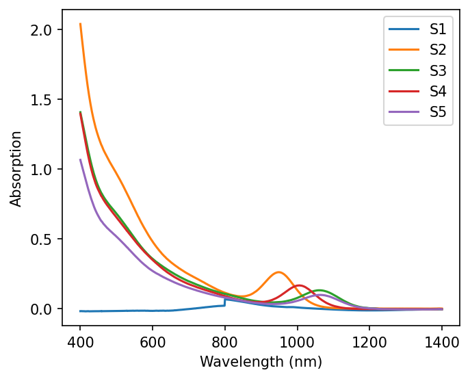

```python
for i in range(1, 6):
    plt.plot(ex1_data.wvl, ex1_data[f"S{i}"], label=f"S{i}")

plt.ylabel("Absorption")
plt.xlabel("Wavelength (nm)")
plt.legend()
```

# Exercise 2* - But I have many files..

```python
files = os.listdir("Cell_Characterization/Spectrophotometry")
```

```python
files.sort()
```

```python
# Separate all the Datasets
rd = [file for file in files if "Rd" in file]
td = [file for file in files if "Td" in file]
rt = [file for file in files if "Rt" in file]
tt = [file for file in files if "Tt" in file]
```

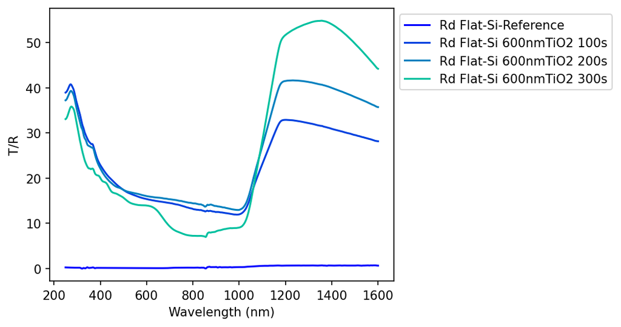

```python
CURR_DATASET = rd
winter = cmap["winter"]
total_files = len(CURR_DATASET)

for index, file in enumerate(CURR_DATASET):
    data = pd.read_csv("Cell_Characterization/Spectrophotometry/"+file,
                        sep=";", decimal=",", names=["wvl", "R"], header=0)
    name_summary = file.split(".")[0].replace("_", " ")
    r_smooth = gaussian_filter1d(data.R, sigma=3)
    plt.plot(data.wvl, r_smooth, color=winter(index/total_files), label=name_summary)
plt.xlabel("Wavelength (nm)")
plt.ylabel("T/R")
plt.legend(bbox_to_anchor=(1, 1))
```

# Exercise 3** - Those strange files...

Consider the file "QD_Characterization/! I_V-t Sampling [(1) ; 14_02_2023 13_26_50].csv", with the current per time for two different samples (I1 and I2) measured twice (top data and bottom data).

Plot the current vs time for both samples for the two measurements.

```python
from io import StringIO

# Read all data as a string
with open("QD_Characterization/! I_V-t Sampling [(1) ; 14_02_2023 13_26_50].csv", "r") as file:
    file_data = file.read()

# Split data from a keyword
split_data = re.split("Dimension1", file_data)

# Cycle though datasets to create a df with all the information
data_df = pd.DataFrame({"Sample": []})
for index, sub_data in enumerate(split_data[1:]):
    import_data = pd.read_csv(StringIO(sub_data), sep=", ",
                              skiprows=2,
                              nrows=1094,
                              engine="python")
    import_data["Sample"] = index
    data_df = data_df.merge(import_data, how="outer")
```

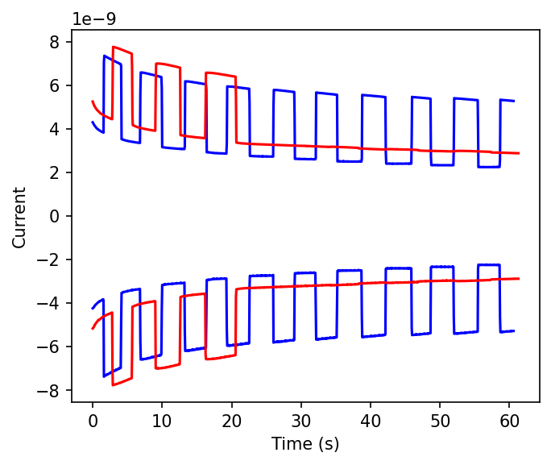

```python
# Make the plots
s1 = data_df[data_df["Sample"] == 0]
s2 = data_df[data_df["Sample"] == 1]
plt.plot(s1["Time"], s1["I1"], "b")
plt.plot(s1["Time"], s1["I2"], "b")
plt.plot(s2["Time"], s2["I1"], "r")
plt.plot(s2["Time"], s2["I2"], "r")
plt.xlabel("Time (s)")
plt.ylabel("Current")
```

# Exercise 4*** - Many coupled files

The data is all provided in "Cell_Electrical_Characterization".

Each file has the Voltage (V), Current (I) and Power (P) measurements for the following setup:

4 cells, each with 3 contacts. Each file represents the measurements between the combinations of the 3 contacts for each cell. The file name is built thus as "c{cell_number}t{contact1}{contact2}.txt"

[figure not shown]

Import the data for all measurements and summarize in a single profile the Pmax for each combination of contacts and for each cell, also adding the average and standard deviation of all the measurements for each cell.

```python
# Importing all data
from itertools import product

contacts = [1, 2, 3]
cells = [1, 2, 3, 4]
contact_combo = product(contacts, contacts)

results_df = pd.DataFrame({"V": [], "A": [], "P": [], "cell": [], "c_combo": []})

for cell, (contact1, contact2) in product(cells, contact_combo):
    sample = f"c{cell}t{contact1}{contact2}"
    data = pd.read_csv(f"Cell_Electrical_Characterization/{sample}.txt",
                       sep=", ", names=["V", "A", "P"], skiprows=1, engine="python")
    data["cell"] = cell
    data["c_combo"] = f"{contact1}{contact2}"
    data["file"] = sample
    results_df = results_df.merge(data, how="outer")
```

### Version 1

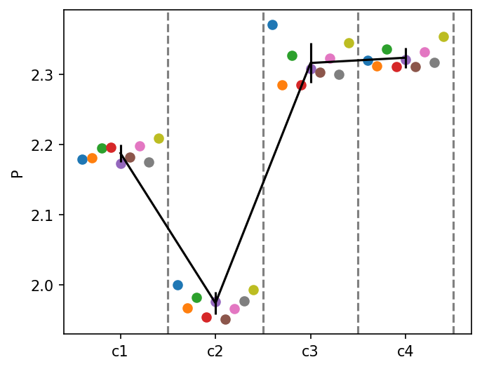

```python
VAR = "P"
# Determine all the maximum results
max_results = results_df.groupby(["cell", "c_combo"], as_index=False).max()
# Determine the max mean and std
summary = max_results.groupby("cell")[VAR].agg(["mean", "std"])
# Plot the error bars
plt.errorbar([5, 15, 25, 35], summary["mean"], yerr=summary["std"], color="black")
# Add line separating sample sets
for i in range(4):
    plt.axvline(x=10+i*10, linestyle="--", color="grey")
# Plot individual cells
subset_positions = np.array([0, 10, 20, 30])
for index, (_, cell_df) in enumerate(max_results.groupby("c_combo")):
    plt.scatter(subset_positions+index+1, cell_df[VAR])
plt.xticks([5, 15, 25, 35], ["c1", "c2", "c3", "c4"])
plt.ylabel(VAR);
```

### Version 2

[figure not shown]

```python
VAR = "V"
# Get maximum value for each file
max_var = results_df.groupby("file").max()[VAR]
cells = ["c1t", "c2t", "c3t", "c4t"]

# Determine average between contact sets
max = [max_var[max_var.index.str.match(cell)].mean()
           for cell in cells]
std = [max_var[max_var.index.str.match(cell)].std()
           for cell in cells]
# Plot the error bars
plt.errorbar([5, 15, 25, 35], max, yerr=std, color="black")
# Add line separating sample sets
for i in range(4):
    plt.axvline(x=10+i*10, linestyle="--", color="grey")
subset_positions = np.array([0, 10, 20, 30])
contacts = ["1", "2", "3"]
for index, (c1, c2) in enumerate(product(contacts, contacts)):
    max_subset = max_var[max_var.index.str.contains(c1+c2)]
    plt.scatter(subset_positions + index+1, max_subset)
plt.xticks([5, 15, 25, 35], ["c1", "c2", "c3", "c4"])
plt.ylabel("Power (W)");
```

```python
def at_max(group):
    """ Function to determine the max I and V of a subgroup """
    max_power = group["P"].max()
    new_res = group[group["P"] == max_power][["A", "V", "P"]]
    return new_res.rename(columns={"P":"Pmax", "A": "Imax", "V": "Vmax"})
results_df.groupby(["cell", "c_combo"]).apply(at_max).head()
```

| cell | c_combo |  | Imax | Vmax | Pmax |
| --- | --- | --- | --- | --- | --- |
| 1 | 11 | 1112 | 0.842874 | 2.586081 | 2.179740 |
|  | 12 | 964 | 0.868888 | 2.510379 | 2.181238 |
|  | 13 | 1028 | 0.862087 | 2.547009 | 2.195743 |
|  | 21 | 954 | 0.876539 | 2.505495 | 2.196164 |
|  | 22 | 989 | 0.860620 | 2.525031 | 2.173091 |

# Exercise 5

## Exercise 5.1 **

Excluding the "Ref" results, make 1 profile for each thickness with the IV curves for all angles.

```python
files = os.listdir("Cell_Characterization/Polars")
files.sort()
```

```python
# Exluce Ref files - for simplicity
files = [ file for file in files if "Ref" not in file ]
```

```python
res_df = pd.DataFrame({"V":[], "I":[], "Type":[], "Angle":[]})
# Create a df with all the datasets
for file in files:
    data = pd.read_csv("Cell_Characterization/Polars/"+file,
                       sep="\t",
                       decimal=",",
                       skiprows=10,
                       usecols=[0, 2],
                       names=["V", "I"])
    # Obtain the angle and cell info
    type = file[10:13]
    data["Type"] = int(type)
    ####
    angle_match = re.search("[0-9]{1,2}deg", file)
    ####
    angle = angle_match.group(0)[:-3]
    data["Angle"] = int(angle)
    res_df = res_df.merge(data, how="outer")
```

```python
res_df
```

|  | V | I | Type | Angle |
| --- | --- | --- | --- | --- |
| 0 | 0.0 | 0.140862 | 400 | 90 |
| 1 | 0.0 | 0.170401 | 800 | 90 |
| 2 | 0.0 | 0.182079 | 500 | 90 |
| 3 | 0.0 | 1.032084 | 400 | 80 |
| 4 | 0.0 | 1.335893 | 500 | 80 |
| ... | ... | ... | ... | ... |
| 2995 | 0.7 | -19.965860 | 400 | 60 |
| 2996 | 0.7 | -19.963900 | 400 | 40 |
| 2997 | 0.7 | -19.963160 | 400 | 30 |
| 2998 | 0.7 | -19.962640 | 400 | 20 |
| 2999 | 0.7 | -19.959410 | 400 | 10 |

3000 rows × 4 columns

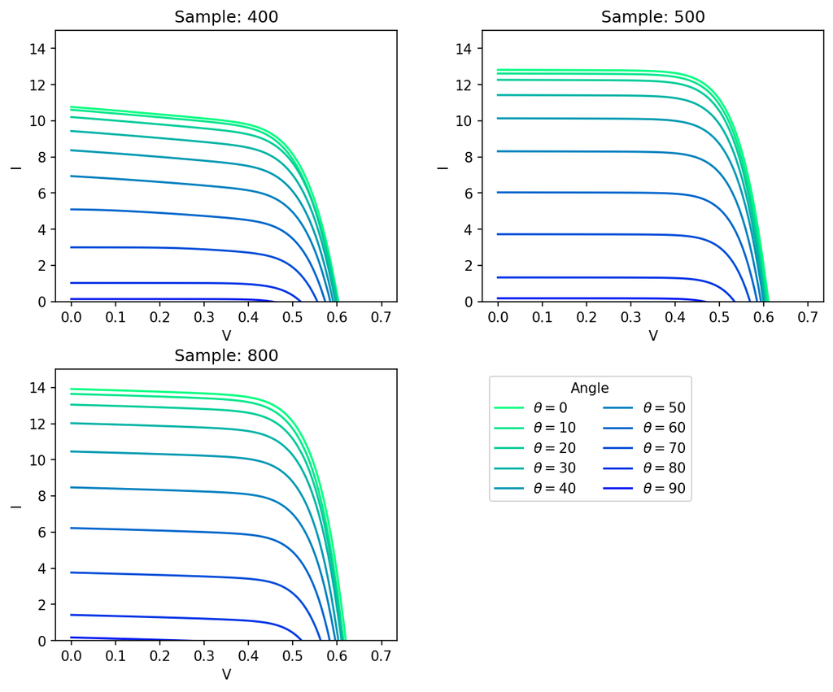

```python
type_group = res_df.groupby("Type")
winter = cmap["winter"]
# Create the 2x2 grid to plot all the datasets
fig, ax = plt.subplots(2, 2, figsize=(10,8),
                       subplot_kw={"ylabel":"I", "xlabel": "V", "ylim": (0, 15)},
                       gridspec_kw={"hspace":0.25, "wspace": 0.25})
for ax_i, (type, type_df) in zip(ax.flatten(), type_group):
    angle_group = type_df.groupby("Angle")
    ax_i.set_title(f"Sample: {type}")
    for index, (angle, angle_df) in enumerate(angle_group):
        ax_i.plot(angle_df.V, angle_df.I, label=rf"$\theta={angle}$",
                  color=winter(1-index/len(angle_group)))

ax[1, 1].axis("off")
ax[1, 0].legend(ncols=2, title="Angle", bbox_to_anchor=(1.25, 1))
```

## Exercise 5.2 ***

For the same data of Exercise 5.1, calculate for each dataset the Voc, Isc, Efficiency and Fill factor of each measurement and make a polar plot of each of those variables with the angular data for each cell thickness.

```python
def jv_params(group):
    """ Calculate JV parameters for JV Curve """
    group["P"] = group["I"]*group["V"]
    max_line = group[group["P"] == group["P"].max()]
    max_line["Pmax"] = group["P"].max()
    max_line["Voc"] = group[group["I"]>0].max()["V"]
    max_line["Isc"] = group["I"].max()
    max_line["Eff"] = max_line["Pmax"]/100
    max_line["FF"] = max_line["I"]*max_line["V"]/(max_line["Isc"]*max_line["Voc"])
    max_line = max_line.drop(["Type", "Angle"], axis=1)
    return max_line
```

```python
# Get the IV summary
summary_df = res_df.groupby(["Type", "Angle"]).apply(jv_params)
# summary_df.to_clipboard()
```

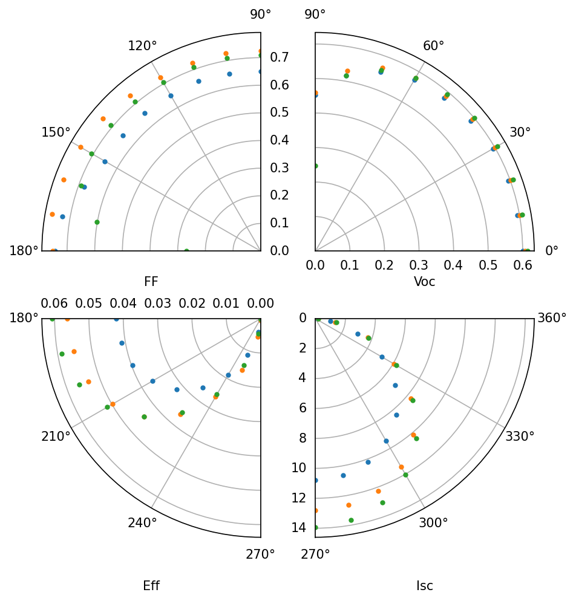

```python
# Create a plot set for the angular plots
fig, ax = plt.subplots(2, 2, figsize=(7, 8),
                       subplot_kw={'projection': 'polar'},
                       gridspec_kw={"wspace":0.25, "hspace":0.05})
vars = ["FF", "Voc", "Eff", "Isc"]
# Angle limits for different plots
angle_lims = [(np.pi/2, np.pi), (0, np.pi/2), (np.pi, 3*np.pi/2), (3*np.pi/2, 2*np.pi)]
for type, type_df in summary_df.groupby("Type"):
    for var, lim, ax_i in zip(vars, angle_lims, ax.flatten()):
        angles = np.radians([angle for _, angle, _ in type_df.index])
        ax_i.plot(angles + lim[0], type_df[var], '.')
        ax_i.set_thetalim(lim)
        ax_i.set_xlabel(var, labelpad=15)
```

# Exercise 6 **** - Complicated files

Import and plot the 1/s (x axis) and mPa.s (y axis) data from "Viscosidade/reol_13.02.2023.csv", for all the different measurements in the file.

## Method 1 - Solving the problem without actually solving the problem

```python
# Open file, remove the \x00 and then write to a new clean file
with open("Viscosidade/reol_13.02.2023.csv", "r", encoding="cp1252") as file:
    text = file.read()
    text = text.replace("\x00", "")

with open("Viscosidade/reol_13.02.2023_clean.csv", "w", encoding="utf8") as file:
    file.write(text.replace("\n\n", "\n"))
```

```python
import re
# Split the file data using the "Test:"
with open("Viscosidade/reol_13.02.2023_clean.csv", "r") as file:
    file_data = file.read()
    split_file = re.split("Test:", file_data)
    search_names = re.findall("Test:\t[a-z0-9_ ]+", file_data)
data_name = [ name[6:] for name in search_names]

# Create a new file for each dataset
for index, file_data in enumerate(split_file[1:]):
    with open(f"Viscosidade/sample_{index}.csv", "w") as new_file:
        new_file.write(file_data)
```

```python
# Use pd.read_csv to import each datafile
res_df_list = []
# Only import the first 12
# The other 2 have less lines to ignore in the top
for i in range(1, 12):
    res_df_list.append(pd.read_csv(
        f"Viscosidade/sample_{i}.csv",
        sep="\t",
        skiprows=19,
        usecols=[2, 3, 4],
        names=["1_s", "Pa", "mPa.s"]))
```

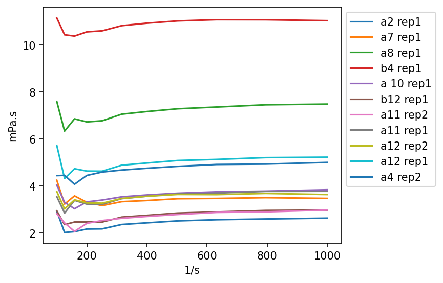

```python
# Plot the results
for res, sample_name in zip(res_df_list, data_name[:-2]):
    plt.plot(res["1_s"], res["mPa.s"], label=sample_name)
plt.xlabel("1/s")
plt.ylabel("mPa.s")
plt.legend(bbox_to_anchor=(1, 1))
```

## Method 2 - Actually Solving the Problem

```python
!file Viscosidade/reol_13.02.2023.csv
```

```
Viscosidade/reol_13.02.2023.csv: Unicode text, UTF-16, little-endian text, with CRLF line terminators
```

```python
from io import StringIO
# This file requires importing with the format utf16
# Import all data
with open("Viscosidade/reol_13.02.2023.csv", "r", encoding="utf16") as file:
    text = file.read()
# Split from interval and data points with more than 2 points
split_text = re.split("Interval and data points:\t[0-9]+\t(?:[2-9]|[0-9]{2,})", text)
# Resplit using "Test:" and get only the
split_text = [ re.split("Test:", curr_test)[0] for curr_test in split_text ]
# Gather sample names
search_names = re.findall("Test:\t[a-z0-9_ ]+", text)
data_name = [name[6:] for name in search_names]
# Iterate to convert everything to df
df_list = [ pd.read_csv(StringIO(dataset),
                        sep="\t", skiprows=5,
                        usecols=[2, 3, 4],
                        names=["1_s", "Pa", "mPa.s"])
           for dataset in split_text[1:] ]
# Joining data
# final_df = df_list[0]
# for df, df_name in zip(df_list[1:], data_name[1:]):
    # final_df = final_df.join(df.set_index("1_s"), on="1_s", rsuffix="_"+df_name)
```

# Exercise 7 - Importing data necessary for other calculations

```python
import glob
files = glob.glob("Ellipsometry/*/*.txt")
```

```python
files
```

```
['Ellipsometry/150/150.29.new.txt',
 'Ellipsometry/150/ZnO150.new.txt',
 'Ellipsometry/150/150.9.txt',
 'Ellipsometry/150/150.15.txt',
 'Ellipsometry/150/150.19.new.txt',
 'Ellipsometry/150/150.39.new.txt',
 'Ellipsometry/180/180.15.new.txt',
 'Ellipsometry/180/180.9.txt',
 'Ellipsometry/180/ZnO.180.txt',
 'Ellipsometry/180/180.39.new.txt',
 'Ellipsometry/180/180.19.new.txt',
 'Ellipsometry/180/180.29.new.txt']
```

```python
# Importing one set of data
Vars = ["t1", "t2", "Eg", "eps_i", "A1", "E1", "C1", "A2", "E2", "C2"]
df_data = []
for file in files:
    with open(file, "r", encoding="iso8859-1") as curr_file:
        filetext = curr_file.read().split("\n")
    data_list = []
    for fileline in filetext[8:18]:
        data = fileline.split("=")[-1].split("ü")[0]
        data_list.append(float(data))
    df_data.append(pd.Series(data_list, index=Vars, name=file.split("/")[-1]))
```

```python
pd.DataFrame(df_data)
```

|  | t1 | t2 | Eg | eps_i | A1 | E1 | C1 | A2 | E2 | C2 |
| --- | --- | --- | --- | --- | --- | --- | --- | --- | --- | --- |
| 150.29.new.txt | 68.328 | 3.548 | 3.260289 | -0.331419 | 128.06550 | 15.590930 | 21.670690 | 459.2356 | 3.133564 | 0.337982 |
| ZnO150.new.txt | 66.564 | 2.384 | 3.195226 | 2.882050 | 51.69330 | 5.737012 | 8.728988 | 279.2493 | 3.273309 | 0.308209 |
| 150.9.txt | 57.794 | 2.311 | 3.432399 | 0.086759 | 116.00670 | 14.521190 | 20.752710 | 359.9405 | 3.160808 | 0.544447 |
| 150.15.txt | 61.062 | 4.934 | 3.316323 | -0.410981 | 129.70220 | 15.673050 | 22.167840 | 315.3058 | 3.109297 | 0.558772 |
| 150.19.new.txt | 63.272 | 3.778 | 3.273024 | 0.440472 | 73.52811 | 11.592070 | 9.706334 | 542.7627 | 3.013803 | 0.365260 |
| 150.39.new.txt | 65.757 | 2.680 | 3.251813 | 2.879839 | 54.30978 | 7.851410 | 12.942430 | 362.9810 | 3.219331 | 0.334511 |
| 180.15.new.txt | 58.041 | 2.862 | 3.382385 | -0.062901 | 159.89180 | 18.367990 | 29.948010 | 644.7813 | 3.084033 | 0.336749 |
| 180.9.txt | 56.898 | 1.633 | 3.444707 | 0.427870 | 82.90215 | 12.359170 | 12.793750 | 667.2075 | 3.064411 | 0.349222 |
| ZnO.180.txt | 65.394 | 2.529 | 3.173462 | 2.811284 | 51.71661 | 6.092115 | 9.285606 | 286.6695 | 3.239832 | 0.308482 |
| 180.39.new.txt | 57.217 | 2.345 | 3.256776 | 2.538374 | 56.42111 | 7.659542 | 12.009900 | 383.8011 | 3.213421 | 0.320847 |
| 180.19.new.txt | 58.023 | 2.348 | 3.315218 | -0.599565 | 129.08760 | 15.410000 | 19.066620 | 579.1666 | 3.075884 | 0.342721 |
| 180.29.new.txt | 60.122 | 2.524 | 3.278637 | 0.590360 | 131.21480 | 15.449080 | 25.212630 | 478.2524 | 3.156034 | 0.324372 |